# Beads community analysis

These are simulated communities. Run the chunks in order from the project root. The aim is to distinguish species richness, evolutionary history, community trait means, and trait dispersion, then compare sites with different habitats.

```r
library(tidyverse)
library(picante)
d <- read_csv("data/samp.csv", show_col_types = FALSE)
trait <- read_csv("data/dummy_trait.csv", show_col_types = FALSE)
env <- read_csv("data/site_environment.csv", show_col_types = FALSE)
tree <- read.tree("data/dummy_tree.newick")

samp <- tapply(d$abund, list(d$Site, d$Species), sum)
# Missing combinations must be verified as absences before replacing NA with 0.
stopifnot(!anyNA(samp), all(samp >= 0), all(rowSums(samp) > 0),
          !anyDuplicated(trait$sp), !anyDuplicated(env$site),
          setequal(colnames(samp), tree$tip.label),
          setequal(colnames(samp), trait$sp),
          setequal(rownames(samp), env$site))
```

## Richness and phylogenetic diversity

PD includes the path to the root (`include.root = TRUE`). MPD and MNTD below use presence/absence, without abundance weighting. Branch lengths are arbitrary units. High richness is intentional: some communities contain all 77 species and therefore have the same presence/absence metrics.

```r
phylo_dm <- cophenetic(tree)
metrics <- tibble(
  site = rownames(samp),
  richness = vegan::specnumber(samp),
  shannon = vegan::diversity(samp),
  PD = pd(samp, tree, include.root = TRUE)$PD,
  MPD = mpd(samp, phylo_dm, abundance.weighted = FALSE),
  MNTD = mntd(samp, phylo_dm, abundance.weighted = FALSE)
) |>
  left_join(env, by = "site")
metrics
```

```
# A tibble: 60 × 12
   site   richness shannon    PD   MPD  MNTD   row   col topo   type      soil_n
   <chr>     <int>   <dbl> <dbl> <dbl> <dbl> <dbl> <dbl> <chr>  <chr>      <dbl>
 1 Site1        77    4.05  19.3  1.28 0.346     1     1 valley Rainfore…  0.271
 2 Site10       65    2.45  17.2  1.31 0.361     4     2 Ridge  Rainfore…  0.316
 3 Site11       66    2.38  17.1  1.27 0.358     5     2 Ridge  Rainfore…  0.307
 4 Site12       67    2.32  17.1  1.28 0.349     6     2 Ridge  Rainfore…  0.244
 5 Site13       77    4.02  19.3  1.28 0.346     1     3 valley Rainfore…  0.306
 6 Site14       77    4.03  19.3  1.28 0.346     2     3 valley Rainfore…  0.304
 7 Site15       77    4.04  19.3  1.28 0.346     3     3 valley Rainfore…  0.346
 8 Site16       69    2.49  17.7  1.29 0.354     4     3 Ridge  Rainfore…  0.341
 9 Site17       66    2.30  16.8  1.28 0.345     5     3 Ridge  Rainfore…  0.298
10 Site18       68    2.20  17.3  1.29 0.347     6     3 Ridge  Rainfore…  0.263
# ℹ 50 more rows
# ℹ 1 more variable: soil_moist <dbl>
```

## Community-weighted means in original units

Each CWM is the sum of abundance × trait divided by total abundance. Align species by name before matrix multiplication. This produces a site × trait matrix. LMA remains in g m<sup>-2</sup>; wood density in g cm<sup>-3</sup>; seed mass in mg.

```r
aligned_trait <- trait[match(colnames(samp), trait$sp), ]
stopifnot(identical(aligned_trait$sp, colnames(samp)))
cwm <- (samp %*% as.matrix(aligned_trait[, -1])) / rowSums(samp)
cwm_sites <- as_tibble(cwm, rownames = "site") |>
  left_join(env, by = "site")
cwm_sites
```

```
# A tibble: 60 × 15
   site     lma    ll a_mass r_mass n_mass p_mass    wd    sm   row   col topo
   <chr>  <dbl> <dbl>  <dbl>  <dbl>  <dbl>  <dbl> <dbl> <dbl> <dbl> <dbl> <chr>
 1 Site1   107.  12.1  164.   19.7   2.88  0.200  0.595 1375.     1     1 valley
 2 Site10  289.  37.1   51.5   7.57  0.985 0.0558 0.686 1438.     4     2 Ridge
 3 Site11  299.  39.4   49.5   7.27  0.960 0.0541 0.691 1398.     5     2 Ridge
 4 Site12  303.  40.3   48.3   7.08  0.946 0.0530 0.694 1394.     6     2 Ridge
 5 Site13  105.  12.8  173.   20.1   2.96  0.203  0.593 1350.     1     3 valley
 6 Site14  109.  12.9  165.   19.7   2.86  0.195  0.598 1406.     2     3 valley
 7 Site15  115.  13.6  158.   19.1   2.75  0.186  0.596 1414.     3     3 valley
 8 Site16  288.  37.0   52.0   7.64  0.991 0.0550 0.685 1429.     4     3 Ridge
 9 Site17  304.  40.0   47.8   7.16  0.945 0.0517 0.696 1417.     5     3 Ridge
10 Site18  312.  41.6   45.2   6.80  0.908 0.0503 0.701 1359.     6     3 Ridge
# ℹ 50 more rows
# ℹ 3 more variables: type <chr>, soil_n <dbl>, soil_moist <dbl>
```

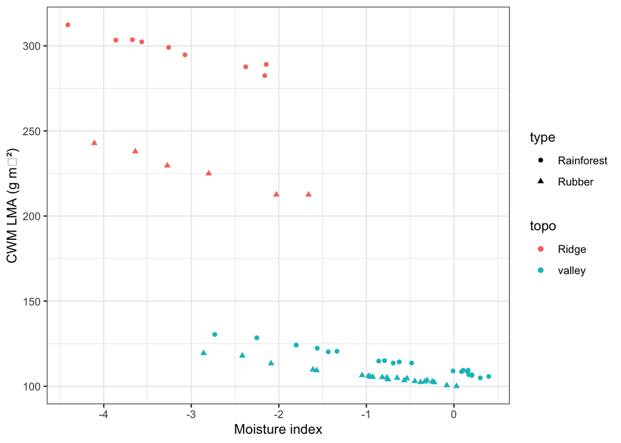

```r
ggplot(cwm_sites, aes(x = soil_moist, y = lma, color = topo, shape = type)) +
  geom_point() +
  labs(x = "Moisture index", y = "CWM LMA (g m⁻²)") +
  theme_bw()
```

Compare CWM with richness: can the dominant strategy change while species richness stays the same? Moisture is associated with topography, so this plot alone cannot isolate their separate effects.

## Functional distances and a null expectation

Use log-transformed traits (except wood density), then standardize each trait. This gives equal variance to each trait, although correlated traits still represent overlapping information. These transformed values are used for distances; the preceding CWM calculation uses original values.

```r
trait_for_distance <- trait |>
  mutate(across(c(lma, ll, a_mass, r_mass, n_mass, p_mass, sm), log))
trait_mat <- scale(as.matrix(trait_for_distance[, -1]))
rownames(trait_mat) <- trait$sp
trait_dm <- as.matrix(dist(trait_mat))
set.seed(123)
functional_mpd <- ses.mpd(samp, trait_dm, abundance.weighted = FALSE,
                          null.model = "taxa.labels", runs = 999)
# Full-pool communities have no label-shuffle variation; mask undefined SES.
full_pool <- rowSums(samp > 0) == nrow(trait_dm)
functional_mpd[full_pool, c("mpd.obs.z", "mpd.obs.p")] <- NA_real_
functional_mpd
```

```
       ntaxa  mpd.obs mpd.rand.mean  mpd.rand.sd mpd.obs.rank  mpd.obs.z
Site1     77 3.799309      3.799309 8.316469e-17        504.0         NA
Site10    65 3.738560      3.799938 5.897791e-02        151.0 -1.0406934
Site11    66 3.766019      3.799090 5.633429e-02        256.0 -0.5870626
Site12    67 3.677477      3.800691 5.070333e-02          8.0 -2.4300887
Site13    77 3.799309      3.799309 8.316469e-17        504.0         NA
Site14    77 3.799309      3.799309 8.316469e-17        504.0         NA
Site15    77 3.799309      3.799309 8.316469e-17        504.0         NA
Site16    69 3.745702      3.799312 4.567404e-02        121.0 -1.1737364
Site17    66 3.690191      3.801012 5.493588e-02         31.0 -2.0172653
Site18    68 3.731821      3.801642 4.830107e-02         86.0 -1.4455352
Site19    77 3.799309      3.799309 8.316469e-17        504.0         NA
Site2     77 3.799309      3.799309 8.316469e-17        504.0         NA
Site20    77 3.799309      3.799309 8.316469e-17        504.0         NA
Site21    77 3.799309      3.799309 8.316469e-17        504.0         NA
Site22    71 3.753921      3.800350 3.906319e-02        128.0 -1.1885551
Site23    68 3.748578      3.800854 4.917650e-02        150.0 -1.0630268
Site24    68 3.708451      3.800604 4.852842e-02         32.0 -1.8989406
Site25    77 3.799309      3.799309 8.316469e-17        504.0         NA
Site26    77 3.799309      3.799309 8.316469e-17        504.0         NA
Site27    77 3.799309      3.799309 8.316469e-17        504.0         NA
Site28    77 3.799309      3.799309 8.316469e-17        504.0         NA
Site29    77 3.799309      3.799309 8.316469e-17        504.0         NA
Site3     77 3.799309      3.799309 8.316469e-17        504.0         NA
Site30    77 3.799309      3.799309 8.316469e-17        504.0         NA
Site31    77 3.799309      3.799309 8.316469e-17        504.0         NA
Site32    77 3.799309      3.799309 8.316469e-17        504.0         NA
Site33    77 3.799309      3.799309 8.316469e-17        504.0         NA
Site34    77 3.799309      3.799309 8.316469e-17        504.0         NA
Site35    77 3.799309      3.799309 8.316469e-17        504.0         NA
Site36    77 3.799309      3.799309 8.316469e-17        504.0         NA
Site37    77 3.799309      3.799309 8.316469e-17        504.0         NA
Site38    77 3.799309      3.799309 8.316469e-17        504.0         NA
Site39    77 3.799309      3.799309 8.316469e-17        504.0         NA
Site4     77 3.799309      3.799309 8.316469e-17        504.0         NA
Site40    77 3.799309      3.799309 8.316469e-17        504.0         NA
Site41    77 3.799309      3.799309 8.316469e-17        504.0         NA
Site42    77 3.799309      3.799309 8.316469e-17        504.0         NA
Site43    75 3.792203      3.799562 2.314747e-02        336.0 -0.3179493
Site44    77 3.799309      3.799309 8.316469e-17        504.0         NA
```

[output cut: 67 more lines]

```
Site50    0.0390  999
Site51    0.2110  999
Site52        NA  999
Site53        NA  999
Site54        NA  999
Site55        NA  999
Site56        NA  999
Site57        NA  999
Site58        NA  999
Site59        NA  999
Site6         NA  999
Site60        NA  999
Site7         NA  999
Site8         NA  999
Site9         NA  999
```

The null model shuffles labels in the trait distance matrix, using the 77 species as the pool while preserving each site’s richness. Negative SES means smaller distances than the null mean; positive SES means larger distances. The sign alone does not establish significance or identify an ecological process. If every species in the pool is present, unweighted MPD is invariant to label shuffles: the null SD is zero apart from numerical rounding, and its SES is not interpretable.